# time-series-prediction-on-the-future-prices-of-bitcoin-using-arima

## ARIMA Models for Time Series Forecasting

In this example, we will build ARIMA and seasonal ARIMA (SARIMA) models to make a time series prediction on the future prices of Bitcoin (BTC).

### Import modules

To import BTC prices using yahoo's stock prices API, we will install yfinance package using the pip package installer for python

```python
pip install yfinance
```

[output not shown]

[output not shown]

```python
# Import libraries
import yfinance as yahooFinance
import datetime
import numpy as np
import pandas as pd
from sklearn.metrics import mean_squared_error
import matplotlib.pyplot as plt
import seaborn as sns
from statsmodels.tsa.statespace.sarimax import SARIMAX
from statsmodels.tsa.arima.model import ARIMA
from statsmodels.tsa.seasonal import seasonal_decompose
```

### Reading and Displaying BTC Time Series Data

Let's read in the historical prices for BTC as a dataframe by defining start and end dates for our data pull. We’ll specifically use the 'Close' price for our forecasting models.

```python
# startDate , as per our convenience we can modify
startDate = datetime.datetime(2018, 1, 1)

# endDate , as per our convenience we can modify
endDate = datetime.datetime(2020, 12, 2)
GetPrices = yahooFinance.Ticker("BTC-USD")

# pass the parameters as the token dates for start and end
prices = GetPrices.history(start=startDate,
                                     end=endDate)

# format the index date field
prices.index = pd.to_datetime(prices.index).strftime('%Y-%m-%d')
prices
```

| Date | Open | High | Low | Close | Volume | Dividends | Stock Splits |
| --- | --- | --- | --- | --- | --- | --- | --- |
| 2018-01-01 | 14112.200195 | 14112.200195 | 13154.700195 | 13657.200195 | 10291200000 | 0.0 | 0.0 |
| 2018-01-02 | 13625.000000 | 15444.599609 | 13163.599609 | 14982.099609 | 16846600192 | 0.0 | 0.0 |
| 2018-01-03 | 14978.200195 | 15572.799805 | 14844.500000 | 15201.000000 | 16871900160 | 0.0 | 0.0 |
| 2018-01-04 | 15270.700195 | 15739.700195 | 14522.200195 | 15599.200195 | 21783199744 | 0.0 | 0.0 |
| 2018-01-05 | 15477.200195 | 17705.199219 | 15202.799805 | 17429.500000 | 23840899072 | 0.0 | 0.0 |
| ... | ... | ... | ... | ... | ... | ... | ... |
| 2020-11-27 | 17153.914062 | 17445.023438 | 16526.423828 | 17108.402344 | 38886494645 | 0.0 | 0.0 |
| 2020-11-28 | 17112.933594 | 17853.939453 | 16910.652344 | 17717.414062 | 32601040734 | 0.0 | 0.0 |
| 2020-11-29 | 17719.634766 | 18283.628906 | 17559.117188 | 18177.484375 | 31133957704 | 0.0 | 0.0 |
| 2020-11-30 | 18178.322266 | 19749.263672 | 18178.322266 | 19625.835938 | 47728480399 | 0.0 | 0.0 |
| 2020-12-01 | 19633.769531 | 19845.974609 | 18321.921875 | 18802.998047 | 49633658712 | 0.0 | 0.0 |

1066 rows × 7 columns

### Writing to CSV

We'll write our data to a csv file to avoid having to repeatedly pull data.

```python
# Write to csv
prices.to_csv("prices.csv")#--by default your file will save in same location as where you saved this jupyter notebook
```

```python
# Import csv
prices = pd.read_csv("prices.csv")
print(prices.head())
```

```
         Date          Open          High           Low         Close  \
0  2018-01-01  14112.200195  14112.200195  13154.700195  13657.200195
1  2018-01-02  13625.000000  15444.599609  13163.599609  14982.099609
2  2018-01-03  14978.200195  15572.799805  14844.500000  15201.000000
3  2018-01-04  15270.700195  15739.700195  14522.200195  15599.200195
4  2018-01-05  15477.200195  17705.199219  15202.799805  17429.500000

        Volume  Dividends  Stock Splits
0  10291200000        0.0           0.0
1  16846600192        0.0           0.0
2  16871900160        0.0           0.0
3  21783199744        0.0           0.0
4  23840899072        0.0           0.0
```

### Setting the Date Index

In order for our model to recognize it's working with time series data, let's set the 'Date' column to be a dataframe index.

```python
# Reset the index as the Date
prices.index = pd.to_datetime(prices['Date'], format='%Y-%m-%d')
del prices['Date']
prices.head()
```

| Date | Open | High | Low | Close | Volume | Dividends | Stock Splits |
| --- | --- | --- | --- | --- | --- | --- | --- |
| 2018-01-01 | 14112.200195 | 14112.200195 | 13154.700195 | 13657.200195 | 10291200000 | 0.0 | 0.0 |
| 2018-01-02 | 13625.000000 | 15444.599609 | 13163.599609 | 14982.099609 | 16846600192 | 0.0 | 0.0 |
| 2018-01-03 | 14978.200195 | 15572.799805 | 14844.500000 | 15201.000000 | 16871900160 | 0.0 | 0.0 |
| 2018-01-04 | 15270.700195 | 15739.700195 | 14522.200195 | 15599.200195 | 21783199744 | 0.0 | 0.0 |
| 2018-01-05 | 15477.200195 | 17705.199219 | 15202.799805 | 17429.500000 | 23840899072 | 0.0 | 0.0 |

### Plotting our time series

Let’s plot our time series data using Seaborn and Matplotlib libraries.

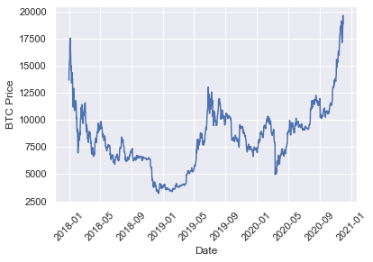

```python
sns.set()
plt.ylabel('BTC Price')
plt.xlabel('Date')
plt.xticks(rotation=45)
plt.plot(prices.index, prices['Close'], )
```

### Decompose Time Series

Let's split our time series using stats model decomposition function to see how much of our data is comprised of trend, seasonality, and noise.

Seasonality: describes the periodic signal in your time series.

Trend: describes whether the time series is decreasing, constant, or increasing over time.

Noise: describes what remains behind the separation of seasonality and trend from the time series. In other words, it’s the variability in the data that cannot be explained by the model.

```python
df = prices[['Close']]
decompose_data = seasonal_decompose(df, model="additive", period=30)
#--we select the Additive model since it appears the trend and seasonal variation are relatively constant
#--we want to analyze by month so we set the period to 30 days.
```

```python
decompose_data.seasonal.plot()
```

[output not shown]

```python
decompose_data.trend.plot()
```

[output not shown]

```python
decompose_data.resid.plot()
```

[output not shown]

### Train/Test Split

We will split our data such that everything before November 2020 will serve as training data, with everything after 2020 becoming the testing data:

```python
train = prices[prices.index < pd.to_datetime("2020-11-01", format='%Y-%m-%d')]
test = prices[prices.index > pd.to_datetime("2020-11-01", format='%Y-%m-%d')]

#plt.plot(train, color = "black")
#plt.plot(test, color = "red")
plt.plot(train.index, train['Close'], color = "black")
plt.plot(test.index, test['Close'], color = "red")
plt.ylabel('BTC Price')
plt.xlabel('Date')
plt.xticks(rotation=45)
plt.title("Train/Test split for BTC Data")
plt.show()
```

[output not shown]

### ARIMA Model

The Autoregressive Integrated Moving Average (ARIMA) model doesn’t assume stationarity (i.e. no trends/seasonality) but does still assume that the data exhibits little to no seasonality. Additionally, the model applies exponential smoothing by adding more weight to recent values and gradually decaying this weight on lag values.

```python
# Lets define our model input
y = train['Close']

ARIMAmodel = ARIMA(y, order = (5, 4, 2))
# The first parameter corresponds to the lagging (past values),
# the second corresponds to differencing (this is what makes
# non-stationary data stationary), and the last parameter corresponds
# to the white noise (for modeling shock events)
ARIMAmodel = ARIMAmodel.fit()

y_pred_2 = ARIMAmodel.get_forecast(len(test.index))
y_pred_df_2 = y_pred_2.conf_int(alpha = 0.05) #--higher alpha assigns greater weight to more recent values
y_pred_df_2["Predictions"] = ARIMAmodel.predict(start = y_pred_df_2.index[0], end = y_pred_df_2.index[-1])
y_pred_df_2.index = test.index
y_pred_out_2 = y_pred_df_2["Predictions"]
```

### SARIMA Model

The seasonal ARIMA (SARIMA) variant is a statistical model that can work with non-stationary data and capture some seasonality.

```python
# Lets define our model input
y = train['Close']

SARIMAXmodel = SARIMAX(y, order = (5, 4, 2), seasonal_order=(2,2,2,12))
# The first 3 parameters for seasonal_order are defined the same as when treating non-seasonal
# The fourth indicates the seasonal periods to apply the parameters to
# In other words, how many observations of seasonal spikes/dips per year
SARIMAXmodel = SARIMAXmodel.fit()

y_pred_3 = SARIMAXmodel.get_forecast(len(test.index))
y_pred_df_3 = y_pred_3.conf_int(alpha = 0.05)
y_pred_df_3["Predictions"] = SARIMAXmodel.predict(start = y_pred_df_3.index[0], end = y_pred_df_3.index[-1])
y_pred_df_3.index = test.index
y_pred_out_3 = y_pred_df_3["Predictions"]
```

### Visualize Results

```python
plt.plot(y_pred_out_3, color='Blue', label = 'SARIMA Predictions')
plt.plot(y_pred_out_2, color='Yellow', label = 'ARIMA Predictions')
plt.plot(train.index, train['Close'], color = "black", label = 'Training')
plt.plot(test.index, test['Close'], color = "red", label = 'Testing')
plt.ylabel('BTC Price')
plt.xlabel('Date')
plt.xticks(rotation=45)
plt.title("Train/Test split for BTC Data")
plt.legend()

sarima_rmse = np.sqrt(mean_squared_error(test["Close"].values, y_pred_df_3["Predictions"]))
print("SARIMA RMSE: ",sarima_rmse)

arima_rmse = np.sqrt(mean_squared_error(test["Close"].values, y_pred_df_2["Predictions"]))
print("ARIMA RMSE: ",arima_rmse)
```

[output not shown]

Reference: For more information about ARIMA and forecasting you can refer to this article from which the above example was derived.

https://builtin.com/data-science/time-series-forecasting-python